# HW 07 Part 1

Donovan Kleinberg

03 January 2019

```r
library(tidyverse)
install.packages("GGally")
library(ggally)
```

[output not shown]

```r
library(GGally)
install.packages("devtools")
```

[output not shown]

[output not shown]

[output not shown]

```r
library(devtools)
```

```r
library(patchwork)
```

Loading sparrows data

```r
file_path <- "C:\\Misc. Files\\BI485 Folder\\Kleinberg_Donovan\\data"
sparrow_raw <- read_tsv(file.path(file_path, "sparrows.txt"), col_names = TRUE)
sparrow_raw
```

| wingcrd | flatwing | tarsus | head | culmen | nalospi | wt | bandstat | initials | Year | Month | Day | Location | SpeciesCode | Sex | Age |
| --- | --- | --- | --- | --- | --- | --- | --- | --- | --- | --- | --- | --- | --- | --- | --- |
| 59.0 | 60.0 | 22.3 | 31.2 | 12.3 | 13.0 | 9.5 | 1 | 2 | 2002 | 9 | 19 | 4 | 1 | 0 | 2 |
| 54.0 | 55.0 | 20.3 | 28.3 | 10.8 | 7.8 | 12.2 | 1 | 2 | 2002 | 10 | 4 | 4 | 3 | 0 | 2 |
| 53.0 | 54.0 | 21.6 | 30.2 | 12.5 | 8.5 | 13.8 | 1 | 2 | 2002 | 10 | 4 | 4 | 3 | 0 | 2 |
| 55.0 | 56.0 | 19.7 | 30.4 | 12.1 | 8.3 | 13.8 | 1 | 8 | 2002 | 7 | 30 | 9 | 1 | 0 | 2 |
| 55.0 | 56.0 | 20.3 | 28.7 | 11.2 | 8.0 | 14.1 | 1 | 3 | 2002 | 10 | 4 | 4 | 3 | 0 | 2 |
| 53.5 | 54.5 | 20.8 | 30.6 | 12.8 | 8.6 | 14.8 | 1 | 7 | 2004 | 8 | 2 | 1 | 1 | 0 | 2 |
| 55.5 | 57.0 | 20.3 | 29.5 | 11.5 | 8.5 | 15.0 | 1 | 3 | 2002 | 10 | 4 | 4 | 3 | 0 | 2 |
| 55.0 | 56.0 | 20.9 | 30.0 | 11.7 | 8.5 | 15.0 | 1 | 3 | 2002 | 10 | 2 | 5 | 3 | 0 | 1 |
| 54.0 | 56.0 | 21.4 | 29.8 | 11.0 | 8.7 | 15.1 | 1 | 1 | 2002 | 10 | 21 | 7 | 3 | 0 | 2 |
| 55.0 | 56.0 | 20.4 | 29.8 | 11.2 | 8.1 | 15.1 | 1 | 2 | 2002 | 10 | 2 | 5 | 3 | 0 | 2 |

[output cut: 990 more lines]

Chunk adds rows needed.

```r
sparrows <- sparrow_raw %>%
  mutate(box_group = "Sparrows",
         row_order = 1:nrow(.))
View(sparrows)
```

Chunk creates initial boxplot

```r
plot_box <- sparrows %>%
  ggplot(aes(x = box_group, y = wingcrd)) +
  geom_boxplot(width = 0.25) +
  labs(x = NULL, y = "Wing Length (mm)")
```

Chunk adds cleveland plot

```r
plot_cleveland <- sparrows %>%
  ggplot(aes(x = wingcrd, y = row_order)) +
  geom_point() +
  labs(x = "Wing Length (mm)", y = "Order of the data")
```

Chunk is stitching the plots together

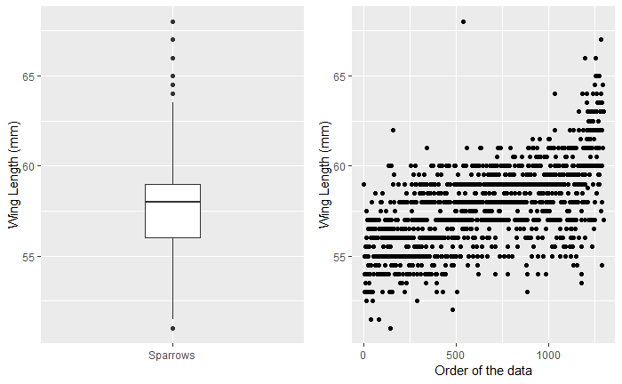

```r
plot_box + plot_cleveland + coord_flip()
```

Figure 3

Chunk begins work on figure 3 by creating all plots and assigning them to variables

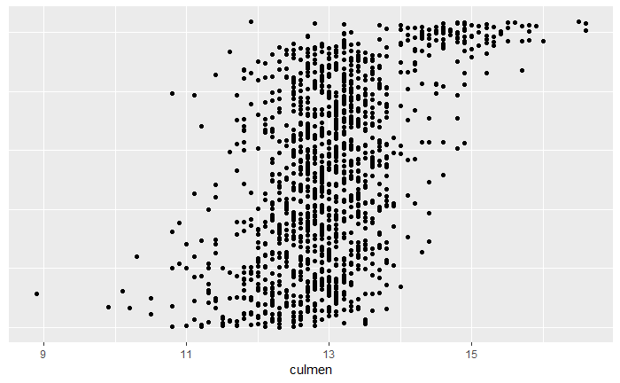

```r
p_culmen <- sparrows %>%
  ggplot(aes(y = row_order)) +
  geom_point(aes(x = culmen)) +
  theme(axis.title.y=element_blank(),
        axis.text.y=element_blank(),
        axis.ticks.y=element_blank())
p_culmen
```

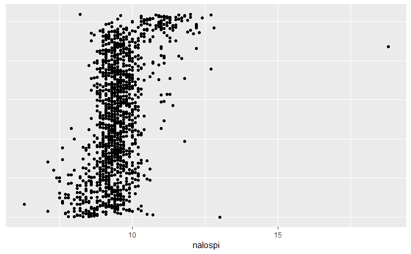

```r
p_nalospi <- sparrows %>%
  ggplot(aes(y = row_order)) +
  geom_point(aes(x = nalospi)) +
  theme(axis.title.y=element_blank(),
        axis.text.y=element_blank(),
        axis.ticks.y=element_blank())
p_nalospi
```

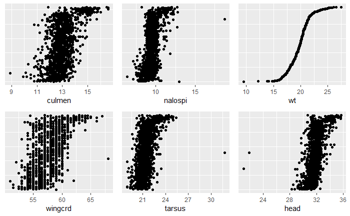

```r
p_wt <- sparrows %>%
  ggplot(aes(y = row_order)) +
  geom_point(aes(x = wt)) +
  theme(axis.title.y=element_blank(),
        axis.text.y=element_blank(),
        axis.ticks.y=element_blank())
p_wingcrd <- sparrows %>%
  ggplot(aes(y = row_order)) +
  geom_point(aes(x = wingcrd)) +
  theme(axis.title.y=element_blank(),
        axis.text.y=element_blank(),
        axis.ticks.y=element_blank())
p_tarsus <- sparrows %>%
  ggplot(aes(y = row_order)) +
  geom_point(aes(x = tarsus)) +
  theme(axis.title.y=element_blank(),
        axis.text.y=element_blank(),
        axis.ticks.y=element_blank())
p_head <- sparrows %>%
  ggplot(aes(y = row_order)) +
  geom_point(aes(x = head)) +
  theme(axis.title.y=element_blank(),
        axis.text.y=element_blank(),
        axis.ticks.y=element_blank())
p_culmen + p_nalospi + p_wt + p_wingcrd + p_tarsus + p_head + plot_layout(nrow = 2)
```

Answer for question regarding figure 3: It would appear the the head, tarsus and nalospi are the variables with extreme outliers.

Figure 5

Chunk plots out histogram

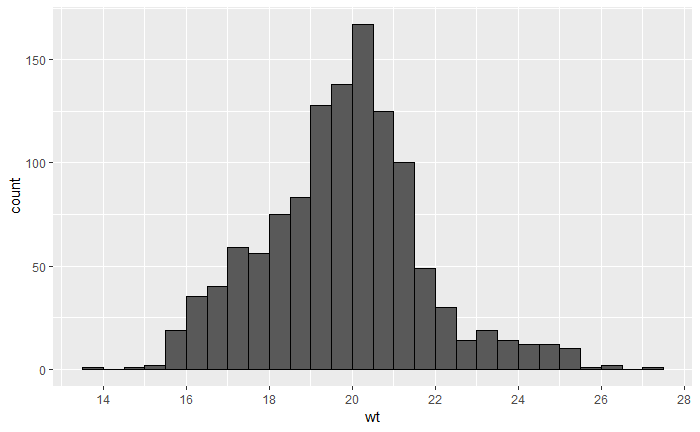

```r
h1 <- sparrows %>%
    filter(Month %in% 6:8) %>%
  ggplot() +
  geom_histogram(aes(x = wt),
                 binwidth = 0.5,
                 boundary = 0,
                 closed = "right",
                 color = "black") +
  scale_x_continuous(breaks = seq(14, 28, by = 2))
h1
```

Chunk plots out second facet histograms

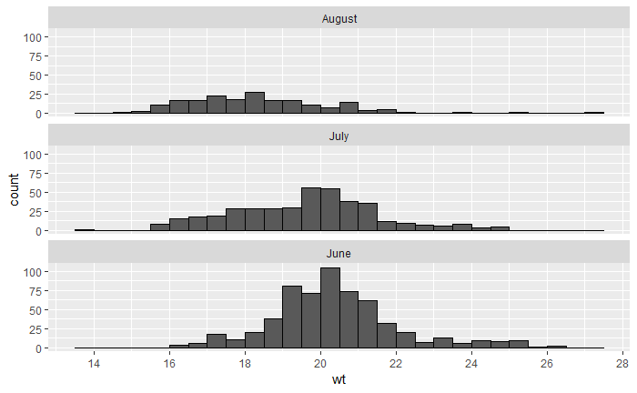

```r
h2 <- sparrows %>%
  filter(Month %in% 6:8) %>%
  mutate(Month = case_when(
    Month == 6 ~ "June",
    Month == 7 ~ "July",
    Month == 8 ~ "August")) %>%
  ggplot() +
  geom_histogram(aes(x = wt),
                 binwidth = 0.5,
                 boundary = 0,
                 color = "black") +
  scale_x_continuous(breaks = seq(14, 28, by = 2)) +
  facet_wrap(~ Month, ncol = 1)
h2
```

Chunk puts h1 and h2 together

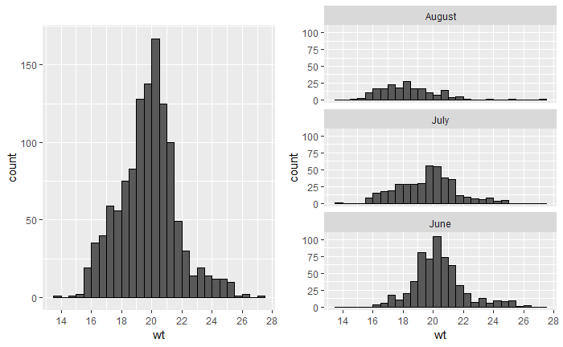

```r
h1 + h2
```

Figure 10

Chunk does scatmat

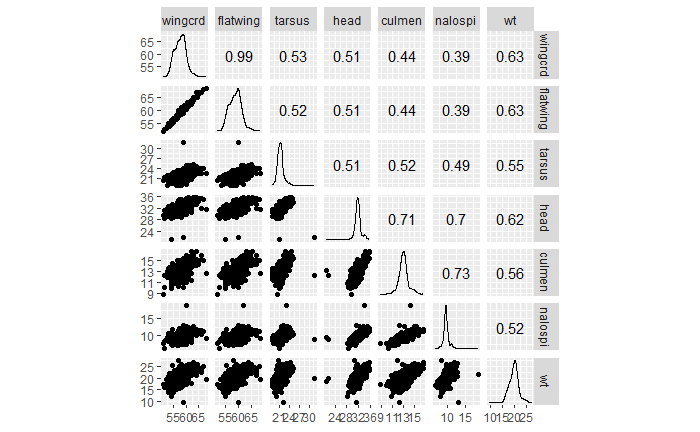

```r
sparrows %>% ggscatmat(columns = 1:7)
```

Figure 11

Chunk runs specified code

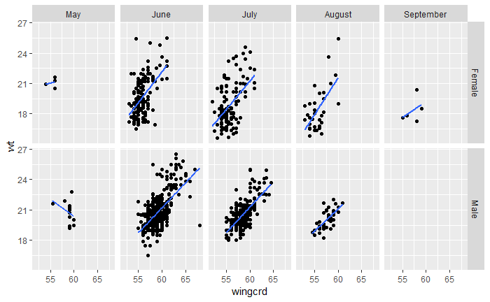

```r
month_order = c("May", "June", "July", "August", "September")
sparrows %>%
  filter(Month %in% 5:9,
         Sex != 0) %>%
  mutate(Month = case_when(
    Month == 5 ~ "May",
    Month == 6 ~ "June",
    Month == 7 ~ "July",
    Month == 8 ~ "August",
    Month == 9 ~ "September"),
    Month = factor(Month, levels = month_order, ordered = TRUE),
    Sex = ifelse(Sex == 4, "Male", "Female")) %>%
  ggplot(aes(x = wingcrd,
             y = wt)) +
  geom_point() +
  geom_smooth(method = "lm", se = FALSE) +
  facet_grid(Sex ~ Month)
```

PART 2 Crabs

```r
raw_crab <- read_csv(file.path(file_path, "aegla_crabs.csv"))
raw_crab
```

| Site | Width | Depth | Flow | AT | WT | pH | TDS | Cond | N | Ni | Nt | Phos | Mg | Ca | Crab | Shrimp | Aeglam | AeglaFe | AeglaFo |
| --- | --- | --- | --- | --- | --- | --- | --- | --- | --- | --- | --- | --- | --- | --- | --- | --- | --- | --- | --- |
| AG1KN1 | 9.0 | 1.70 | 0.47 | 19.3 | 18.6 | 6.76 | 22 | 45 | 0.09 | 0.130 | 0.000 | 0.880 | 3.51 | 0.05 | NA | NA | NA | NA | NA |
| AG1KN2 | 7.0 | 1.40 | 0.43 | 19.1 | 18.2 | 6.99 | 17 | 34 | 0.00 | 0.110 | 0.000 | 0.000 | 4.00 | 0.02 | 4 | 2 | 24 | 4 | 22 |
| AG1KN3 | 6.0 | 1.20 | 0.43 | 19.5 | 18.4 | 7.01 | 23 | 42 | 0.00 | 0.120 | 0.000 | 0.000 | 4.00 | 0.03 | 6 | 10 | 24 | 0 | 8 |
| RJMHQ4 | 9.0 | 2.50 | 0.70 | 19.5 | 18.5 | 6.99 | 6 | 12 | 0.03 | 0.010 | 0.001 | 0.030 | 1.57 | 1.93 | 0 | 4 | 0 | 0 | 0 |
| AG1KN5 | 3.0 | 0.70 | 0.40 | 20.9 | 17.4 | 6.99 | 25 | 50 | 0.00 | 0.100 | 0.000 | 0.000 | 4.00 | 0.00 | 1 | 8 | 8 | 0 | 1 |
| RJMHQ6 | 9.0 | 2.50 | 0.70 | 20.9 | 18.2 | 6.91 | 9 | 18 | 0.03 | 0.010 | 0.001 | 0.030 | 1.57 | 1.93 | 0 | 3 | 0 | 0 | 0 |
| AG1KN7 | 3.0 | 0.70 | 0.40 | 21.9 | 17.0 | 7.53 | 29 | 58 | 0.01 | 0.130 | 0.000 | 0.070 | 3.84 | 0.00 | 2 | 8 | 29 | 0 | 19 |
| RJMHQ7 | 9.0 | 2.50 | 0.70 | 22.4 | 17.7 | 6.99 | 9 | 18 | 0.04 | 0.070 | 0.001 | 0.040 | 2.84 | 4.00 | 0 | 2 | 0 | 0 | 0 |
| AG1KN8 | 2.5 | 0.50 | 0.40 | 19.3 | 18.0 | 7.54 | 25 | 54 | 0.03 | 0.120 | 0.000 | 0.120 | 4.00 | 0.00 | 5 | 13 | 26 | 5 | 17 |
| RJMHQ8 | 8.0 | 2.00 | 0.70 | 19.6 | 18.0 | 6.98 | 11 | 23 | 0.03 | 0.110 | 0.000 | 0.030 | 2.66 | 1.09 | 0 | 2 | 0 | 0 | 0 |

[output cut: 46 more lines]

Chunk selects and removes columns

```r
crabs_selected <- select(raw_crab, -Site, -AT, -WT, -Shrimp, -Aeglam, -AeglaFe, -AeglaFo)
crabs_selected
```

| Width | Depth | Flow | pH | TDS | Cond | N | Ni | Nt | Phos | Mg | Ca | Crab |
| --- | --- | --- | --- | --- | --- | --- | --- | --- | --- | --- | --- | --- |
| 9.0 | 1.70 | 0.47 | 6.76 | 22 | 45 | 0.09 | 0.130 | 0.000 | 0.880 | 3.51 | 0.05 | NA |
| 7.0 | 1.40 | 0.43 | 6.99 | 17 | 34 | 0.00 | 0.110 | 0.000 | 0.000 | 4.00 | 0.02 | 4 |
| 6.0 | 1.20 | 0.43 | 7.01 | 23 | 42 | 0.00 | 0.120 | 0.000 | 0.000 | 4.00 | 0.03 | 6 |
| 9.0 | 2.50 | 0.70 | 6.99 | 6 | 12 | 0.03 | 0.010 | 0.001 | 0.030 | 1.57 | 1.93 | 0 |
| 3.0 | 0.70 | 0.40 | 6.99 | 25 | 50 | 0.00 | 0.100 | 0.000 | 0.000 | 4.00 | 0.00 | 1 |
| 9.0 | 2.50 | 0.70 | 6.91 | 9 | 18 | 0.03 | 0.010 | 0.001 | 0.030 | 1.57 | 1.93 | 0 |
| 3.0 | 0.70 | 0.40 | 7.53 | 29 | 58 | 0.01 | 0.130 | 0.000 | 0.070 | 3.84 | 0.00 | 2 |
| 9.0 | 2.50 | 0.70 | 6.99 | 9 | 18 | 0.04 | 0.070 | 0.001 | 0.040 | 2.84 | 4.00 | 0 |
| 2.5 | 0.50 | 0.40 | 7.54 | 25 | 54 | 0.03 | 0.120 | 0.000 | 0.120 | 4.00 | 0.00 | 5 |
| 8.0 | 2.00 | 0.70 | 6.98 | 11 | 23 | 0.03 | 0.110 | 0.000 | 0.030 | 2.66 | 1.09 | 0 |

[output cut: 46 more lines]

```r
crabsclean <- drop_na(crabs_selected)
```

Chunk adds dummy variable.

```r
crabs_wrang <- crabs_clean %>%
   mutate(row_order = 1:nrow(.))
crabs_wrang
```

[output not shown]

[output cut: 46 more lines]

Chunk creates variables to explore the data

```r
p_width <- crabs_wrang %>%
  ggplot(aes(x =Width))+
  geom_point(aes(y = row_order))
p_depth <- crabs_wrang %>%
  ggplot(aes(x = Depth))+
  geom_point(aes(y = row_order))
p_flow <- crabs_wrang %>%
  ggplot(aes(x = Flow))+
  geom_point(aes(y = row_order))
p_ph <- crabs_wrang %>%
  ggplot(aes(x = pH))+
  geom_point(aes(y = row_order))
p_tds <- crabs_wrang %>%
  ggplot(aes(x = TDS))+
  geom_point(aes(y = row_order))
p_cond<- crabs_wrang %>%
  ggplot(aes(x = Cond))+
  geom_point(aes(y = row_order))
p_n <- crabs_wrang %>%
  ggplot(aes(x = N))+
  geom_point(aes(y = row_order))
p_ni <- crabs_wrang %>%
  ggplot(aes(x = Ni))+
  geom_point(aes(y = row_order))
p_nt <- crabs_wrang %>%
  ggplot(aes(x = Nt))+
  geom_point(aes(y = row_order))
p_phos <- crabs_wrang %>%
  ggplot(aes(x = Phos))+
  geom_point(aes(y = row_order))
p_mg <- crabs_wrang %>%
  ggplot(aes(x = Mg))+
  geom_point(aes(y = row_order))
p_ca <- crabs_wrang %>%
  ggplot(aes(x = Ca))+
  geom_point(aes(y = row_order))
p_crab <- crabs_wrang %>%
  ggplot(aes(x = Crab))+
  geom_point(aes(y = row_order))
```

Chunk contains variables plotted to determine extreme outliers.

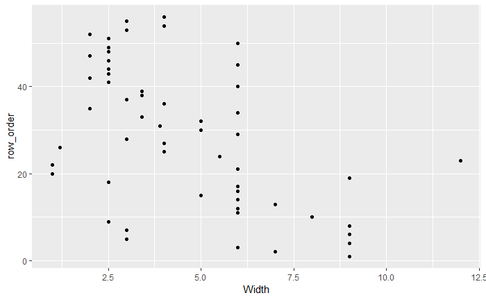

```r
p_width
```

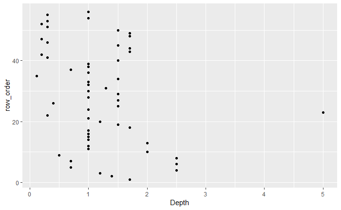

```r
p_depth
```

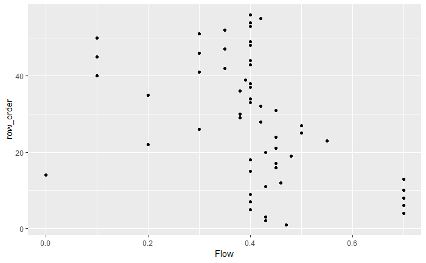

```r
p_flow
```

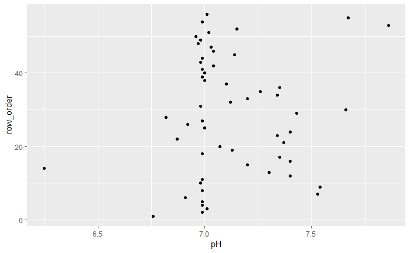

```r
p_ph
```

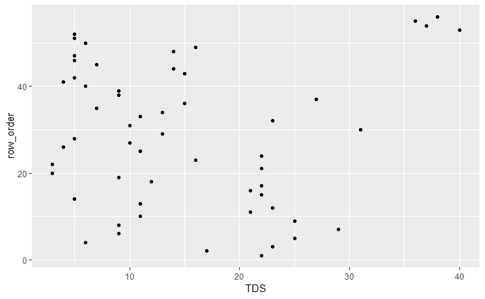

```r
p_tds
```

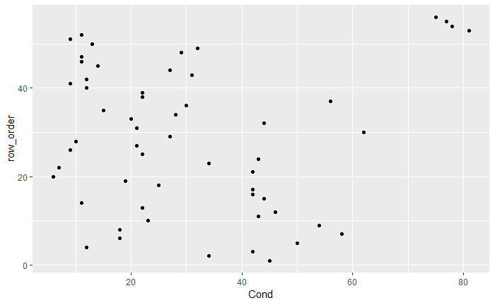

```r
p_cond
```

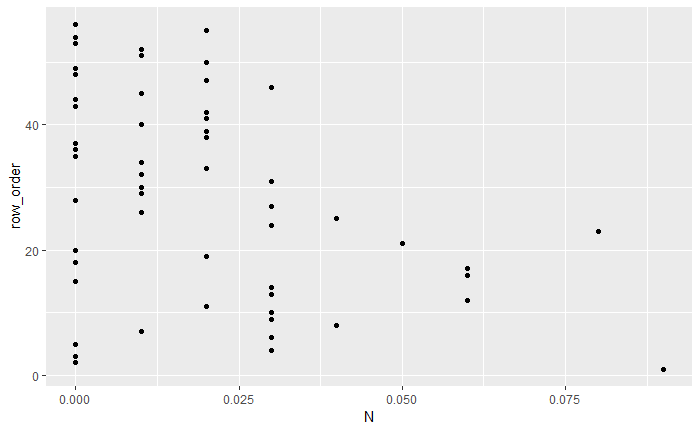

```r
p_n
```

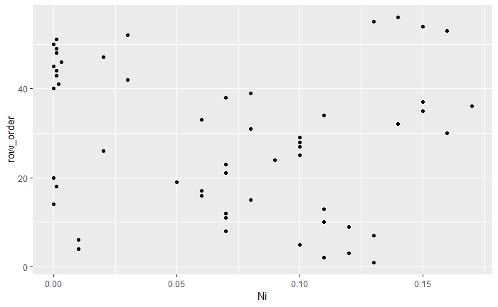

```r
p_ni
```

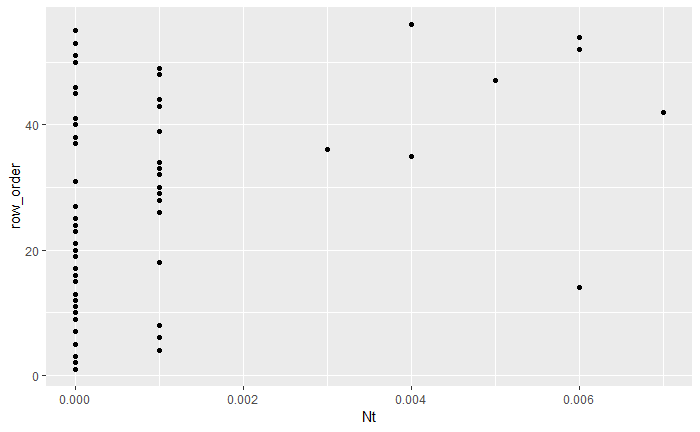

```r
p_nt
```

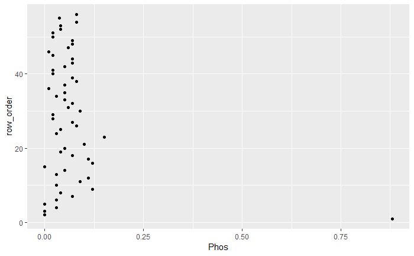

```r
p_phos
```

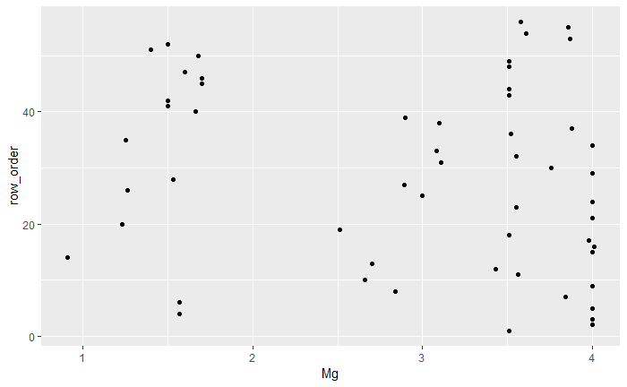

```r
p_mg
```

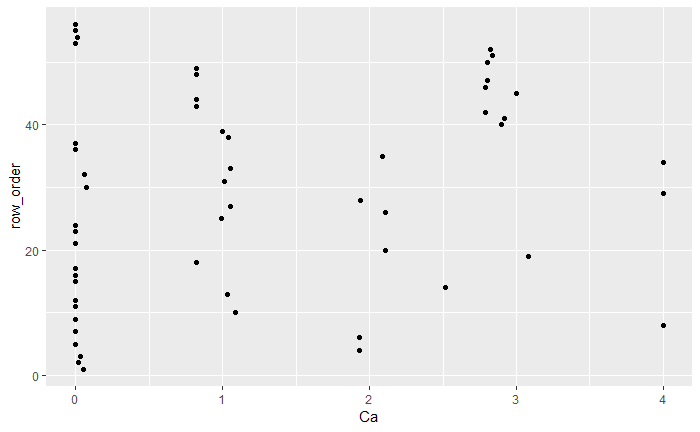

```r
p_ca
```

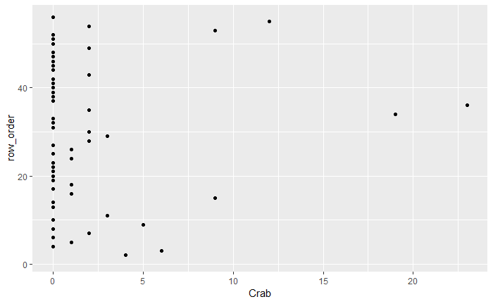

```r
p_crab
```

Discussion regarding outliers. I believe Depth and pH both have data that somewhat resembles outliers with depth having a single measurement 2 meters deeper than the others and pH having a measurement around row order 15 that is a little lower than any other. However, Phos has the one true outlier with a measurement near row 0 that is much greater, around 0.75 compared to the rest which hover near 0.06 - 0.12.

Chunk has the 4 Cleveland plots.

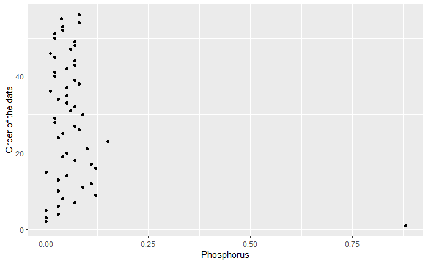

```r
### Cleveland 1
cleve_one <-  crabs_wrang %>%
  ggplot(aes(x = Phos, y = row_order)) +
  geom_point() +
  labs(x = "Phosphorus", y = "Order of the data")
cleve_one
```

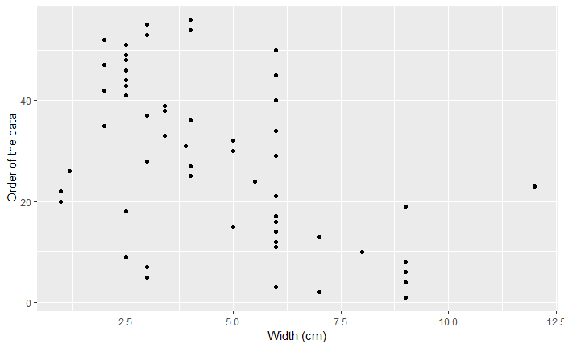

```r
### Cleveland 2
cleve_two <-  crabs_wrang %>%
  ggplot(aes(x = Width, y = row_order)) +
  geom_point() +
  labs(x = "Width (cm)", y = "Order of the data")
cleve_two
```

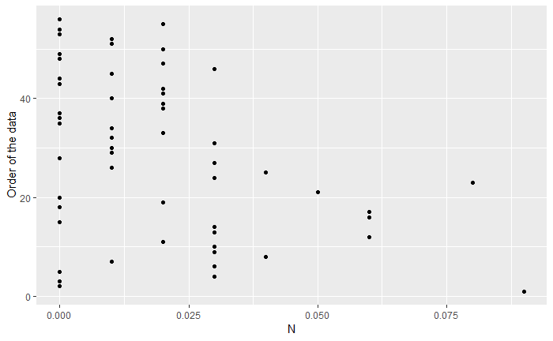

```r
### Cleveland 3
cleve_three <-  crabs_wrang %>%
  ggplot(aes(x = N, y = row_order)) +
  geom_point() +
  labs(x = "N", y = "Order of the data")
cleve_three
```

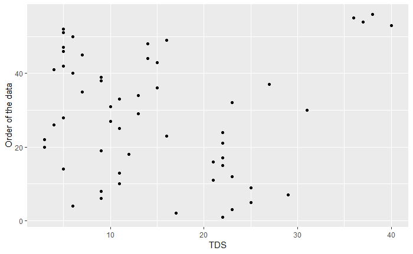

```r
### Cleveland 4
cleve_four <-  crabs_wrang %>%
  ggplot(aes(x = TDS, y = row_order)) +
  geom_point() +
  labs(x = "TDS", y = "Order of the data")
cleve_four
```

Chunk uses patchwork to stitch the 4 clevelands together

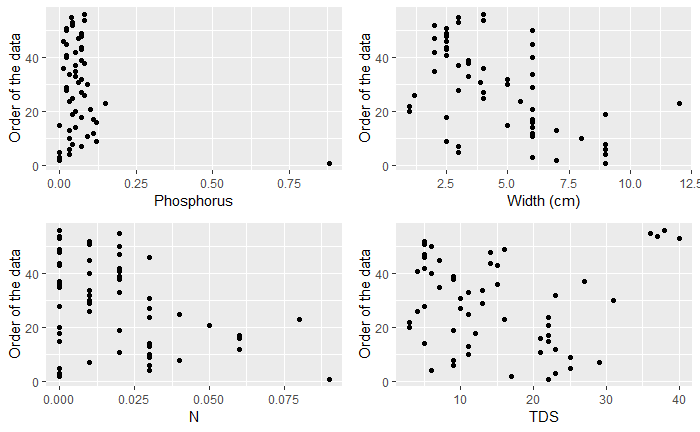

```r
cleve_one + cleve_two + cleve_three + cleve_four + plot_layout(ncol = 2)
```

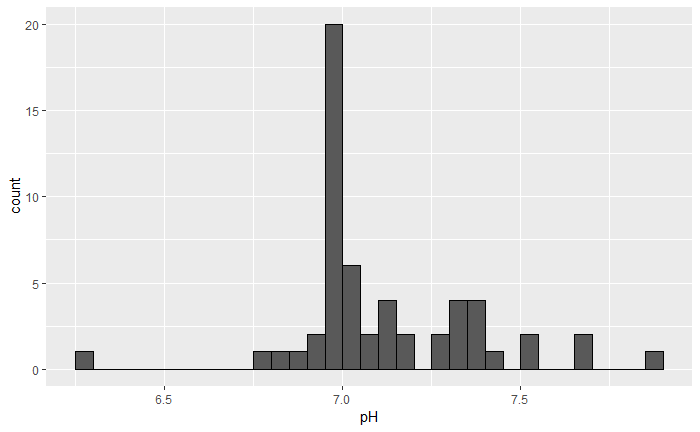

```r
### Histogram 1
histo_one <- ggplot(data = crabs_wrang)+
  geom_histogram(aes(x = pH),
                 binwidth = .05,
                 boundary = 0,
                 closed = "right",
                 color = "black")
histo_one
```

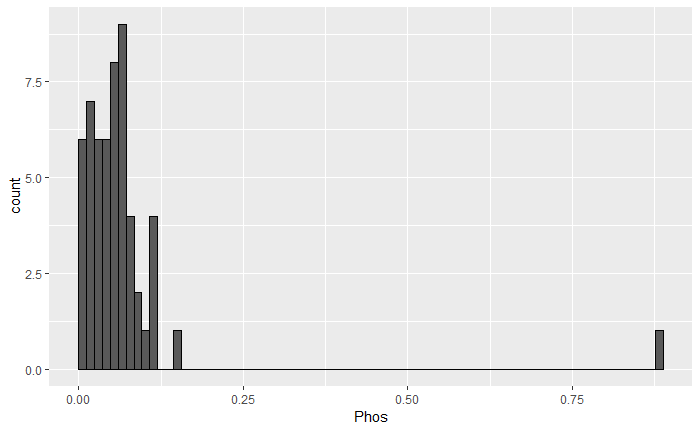

```r
### Histogram 2
histo_two <- ggplot(data = crabs_wrang)+
  geom_histogram(aes(x = Phos),
                 binwidth = .012,
                 boundary = 0,
                 closed = "right",
                 color = "black")
histo_two
```